# Lab Experiment 5: Linear Regression through Gradient Descent

**Aim:** Implement Linear Regression using Gradient Descent and evaluate it on the Student Performance dataset.

Dataset used: `student-mat.csv` (Math course) from the UCI Student Performance dataset.

## 1. Import Libraries

```python
import numpy as np
import pandas as pd
import matplotlib.pyplot as plt

from sklearn.model_selection import train_test_split
from sklearn.preprocessing import StandardScaler
from sklearn.metrics import mean_absolute_error, mean_squared_error, r2_score
```

## 2. Load the Dataset

The file is semicolon separated, so sep=';' is needed.

```python
df = pd.read_csv("data/student-mat.csv", sep=';')
print(df.shape)
df.head()
```

```
(395, 33)
```

|  | school | sex | age | address | famsize | Pstatus | Medu | Fedu | Mjob | Fjob | ... | famrel | freetime | goout | Dalc | Walc | health | absences | G1 | G2 | G3 |
| --- | --- | --- | --- | --- | --- | --- | --- | --- | --- | --- | --- | --- | --- | --- | --- | --- | --- | --- | --- | --- | --- |
| 0 | GP | F | 18 | U | GT3 | A | 4 | 4 | at_home | teacher | ... | 4 | 3 | 4 | 1 | 1 | 3 | 6 | 5 | 6 | 6 |
| 1 | GP | F | 17 | U | GT3 | T | 1 | 1 | at_home | other | ... | 5 | 3 | 3 | 1 | 1 | 3 | 4 | 5 | 5 | 6 |
| 2 | GP | F | 15 | U | LE3 | T | 1 | 1 | at_home | other | ... | 4 | 3 | 2 | 2 | 3 | 3 | 10 | 7 | 8 | 10 |
| 3 | GP | F | 15 | U | GT3 | T | 4 | 2 | health | services | ... | 3 | 2 | 2 | 1 | 1 | 5 | 2 | 15 | 14 | 15 |
| 4 | GP | F | 16 | U | GT3 | T | 3 | 3 | other | other | ... | 4 | 3 | 2 | 1 | 2 | 5 | 4 | 6 | 10 | 10 |

5 rows × 33 columns

The dataset has 395 students and 33 columns covering demographics (age, sex, address type), family background (parents' education and jobs, family size), school-related factors (study time, past failures, extra support, absences), social habits (going out, alcohol consumption, free time) and the three period grades `G1`, `G2`, `G3`. It's a mix of numeric, binary yes/no, and multi-category text columns, so each type needs different preprocessing before it can be used in gradient descent, which only works with numeric input.

## 3. Check for Missing Values

```python
df.isnull().sum().sum()  # total missing values in the dataset
```

```
np.int64(0)
```

No missing values in this dataset, so nothing to impute here.

## 4. Encode Categorical Variables

Most columns in this dataset are yes/no or two category text fields, so instead of one hot encoding everything we just map the ones we plan to use to 0/1.

- `sex`: student's gender (F = female, M = male)
- `schoolsup`: extra educational support from the school (yes/no)
- `higher`: wants to pursue higher education (yes/no)
- `internet`: internet access at home (yes/no)

```python
df['sex'] = df['sex'].map({'F': 0, 'M': 1})
df['schoolsup'] = df['schoolsup'].map({'yes': 1, 'no': 0})
df['higher'] = df['higher'].map({'yes': 1, 'no': 0})
df['internet'] = df['internet'].map({'yes': 1, 'no': 0})

df[['sex', 'schoolsup', 'higher', 'internet']].head()
```

|  | sex | schoolsup | higher | internet |
| --- | --- | --- | --- | --- |
| 0 | 0 | 1 | 1 | 0 |
| 1 | 0 | 0 | 1 | 1 |
| 2 | 0 | 1 | 1 | 1 |
| 3 | 0 | 0 | 1 | 1 |
| 4 | 0 | 0 | 1 | 0 |

## 5. Select Input Features and Target

Target: `G3` (final grade)

`G1`, `G2` and `G3` are grades (0-20) for the same course at three points in the year: first period, second period and final.

Features picked: a mix of demographic, behavioural and past performance columns. `G1` and `G2` are included since they are strong predictors of the final grade in this dataset.

```python
features = ['sex', 'age', 'studytime', 'failures', 'schoolsup',
            'higher', 'internet', 'absences', 'G1', 'G2']

X = df[features].values
y = df['G3'].values.reshape(-1, 1)

print(X.shape, y.shape)
```

```
(395, 10) (395, 1)
```

## 6. Train Test Split

```python
X_train, X_test, y_train, y_test = train_test_split(
    X, y, test_size=0.2, random_state=42
)

print("Train size:", X_train.shape[0])
print("Test size:", X_test.shape[0])
```

```
Train size: 316
Test size: 79
```

## 7. Feature Scaling

Gradient descent converges much better when features are on the same scale, so we standardize using `StandardScaler`. The scaler is fit only on the training data and then used to transform the test data, to avoid leaking information from the test set.

```python
scaler = StandardScaler()
X_train_scaled = scaler.fit_transform(X_train)
X_test_scaled = scaler.transform(X_test)

# add a bias (intercept) column of ones
X_train_b = np.c_[np.ones((X_train_scaled.shape[0], 1)), X_train_scaled]
X_test_b = np.c_[np.ones((X_test_scaled.shape[0], 1)), X_test_scaled]

print(X_train_b.shape, X_test_b.shape)
```

```
(316, 11) (79, 11)
```

## 8. Gradient Descent Implementation

`compute_cost` returns the Mean Squared Error (halved, the usual convention for a cleaner gradient). `gradient_descent` runs batch gradient descent for a fixed number of iterations and keeps track of the cost at every step so we can plot it later.

```python
def compute_cost(X, y, theta):
    m = len(y)
    predictions = X.dot(theta)
    return (1 / (2 * m)) * np.sum((predictions - y) ** 2)


def gradient_descent(X, y, theta, learning_rate, iterations):
    m = len(y)
    cost_history = []

    for i in range(iterations):
        predictions = X.dot(theta)
        error = predictions - y
        gradients = (1 / m) * X.T.dot(error)
        theta = theta - learning_rate * gradients
        cost_history.append(compute_cost(X, y, theta))

    return theta, cost_history
```

## 9. Trying Different Learning Rates

Before settling on a final model, it helps to see how the learning rate affects convergence. A learning rate that is too small barely moves in 100 iterations, and one that is too large can overshoot the minimum or even diverge.

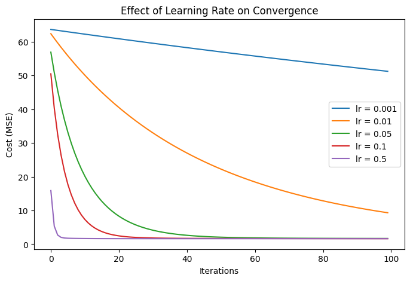

```python
n_features = X_train_b.shape[1]
learning_rates = [0.001, 0.01, 0.05, 0.1, 0.5]
iterations_test = 100

plt.figure(figsize=(8, 5))

for lr in learning_rates:
    theta_init = np.zeros((n_features, 1))
    _, cost_history = gradient_descent(X_train_b, y_train, theta_init, lr, iterations_test)
    plt.plot(cost_history, label=f"lr = {lr}")

plt.xlabel("Iterations")
plt.ylabel("Cost (MSE)")
plt.title("Effect of Learning Rate on Convergence")
plt.legend()
plt.show()
```

Small learning rates like 0.001 and 0.01 are still coming down slowly after 100 iterations, while 0.1 and 0.5 have basically flattened out already. To see what happens when the learning rate is pushed too far, here is the same run with `lr = 1.0` for just a few iterations.

```python
theta_init = np.zeros((n_features, 1))
_, cost_history_high = gradient_descent(X_train_b, y_train, theta_init, 1.0, 6)

for i, c in enumerate(cost_history_high):
    print(f"Iteration {i}: cost = {c:.2f}")
```

```
Iteration 0: cost = 14.55
Iteration 1: cost = 24.84
Iteration 2: cost = 44.24
Iteration 3: cost = 80.21
Iteration 4: cost = 146.73
Iteration 5: cost = 269.68
```

Instead of going down, the cost blows up every iteration. This is the classic sign of a learning rate that is too high, the steps taken are so large that the parameters overshoot the minimum and keep moving further away from it instead of settling down.

## 10. Final Model Training

Based on the comparison above, `lr = 0.1` gives fast, stable convergence, so that is used for the final model with a larger number of iterations to make sure it has fully settled.

```python
learning_rate = 0.1
iterations = 1000

theta_init = np.zeros((n_features, 1))
theta_final, loss_history = gradient_descent(X_train_b, y_train, theta_init, learning_rate, iterations)

print("Final cost:", loss_history[-1])
```

```
Final cost: 1.6415678348441687
```

## 11. Loss vs Iterations

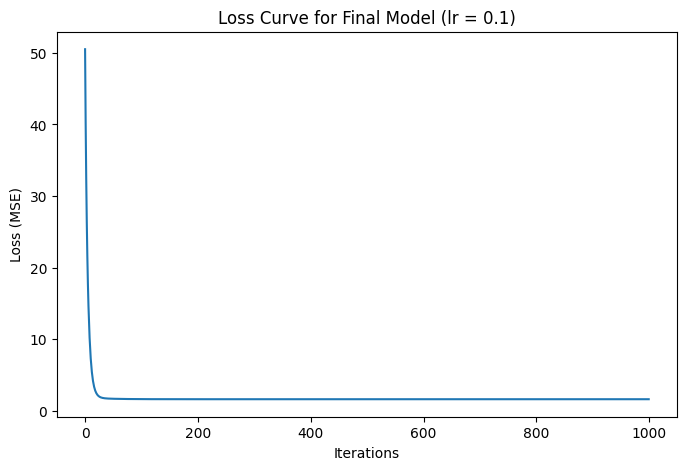

```python
plt.figure(figsize=(8, 5))
plt.plot(loss_history)
plt.xlabel("Iterations")
plt.ylabel("Loss (MSE)")
plt.title("Loss Curve for Final Model (lr = 0.1)")
plt.show()
```

The loss drops sharply in the first 100 or so iterations and then flattens out, which means the model has converged well before reaching iteration 1000.

## 12. Visualizing the Gradient Descent Path

The loss curve above shows cost dropping over time, but it doesn't show *how* gradient descent moves through parameter space to get there. To see that, we track two of the model's weights (the bias term and the weight for `G2`, the strongest predictor) at every iteration, then plot them against a 3D surface of the cost function for just those two dimensions (all other weights held fixed at their final trained values). Since MSE is a convex function of the weights, the surface is a bowl shape, and the red path traces the actual route gradient descent took from `(0, 0)` down toward the minimum.

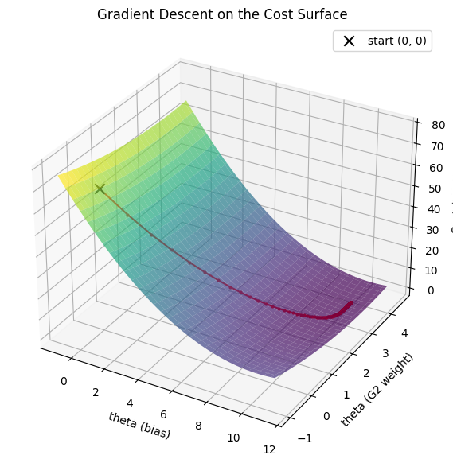

```python
from mpl_toolkits.mplot3d import Axes3D  # noqa: F401 (registers the 3D projection)

idx_g2 = features.index('G2') + 1  # +1 to account for the bias column at index 0

# rerun gradient descent, this time recording (bias, G2 weight, cost) at every step
theta = np.zeros((n_features, 1))
theta_path = [theta.flatten().copy()]
cost_path = [compute_cost(X_train_b, y_train, theta)]

for i in range(iterations):
    predictions = X_train_b.dot(theta)
    error = predictions - y_train
    gradients = (1 / len(y_train)) * X_train_b.T.dot(error)
    theta = theta - learning_rate * gradients
    theta_path.append(theta.flatten().copy())
    cost_path.append(compute_cost(X_train_b, y_train, theta))

theta_path = np.array(theta_path)
cost_path = np.array(cost_path)

# build a cost surface over the (bias, G2 weight) plane, other weights fixed at their final values
theta0_vals = np.linspace(theta_path[:, 0].min() - 1, theta_path[:, 0].max() + 1, 60)
theta_g2_vals = np.linspace(theta_path[:, idx_g2].min() - 1, theta_path[:, idx_g2].max() + 1, 60)
theta0_grid, theta_g2_grid = np.meshgrid(theta0_vals, theta_g2_vals)

cost_grid = np.zeros_like(theta0_grid)
theta_fixed = theta_final.flatten().copy()

for i in range(theta0_grid.shape[0]):
    for j in range(theta0_grid.shape[1]):
        t = theta_fixed.copy()
        t[0] = theta0_grid[i, j]
        t[idx_g2] = theta_g2_grid[i, j]
        cost_grid[i, j] = compute_cost(X_train_b, y_train, t.reshape(-1, 1))

fig = plt.figure(figsize=(9, 7))
ax = fig.add_subplot(111, projection='3d')
ax.plot_surface(theta0_grid, theta_g2_grid, cost_grid, cmap='viridis', alpha=0.7, edgecolor='none')
ax.plot(theta_path[:, 0], theta_path[:, idx_g2], cost_path, color='red', marker='o', markersize=2, linewidth=1.5)
ax.scatter(theta_path[0, 0], theta_path[0, idx_g2], cost_path[0], color='black', marker='x', s=80, label='start (0, 0)')
ax.set_xlabel('theta (bias)')
ax.set_ylabel('theta (G2 weight)')
ax.set_zlabel('Cost (MSE)')
ax.set_title('Gradient Descent on the Cost Surface')
ax.legend()
plt.show()
```

## 13. Evaluate on Test Set

```python
y_pred = X_test_b.dot(theta_final)

mae = mean_absolute_error(y_test, y_pred)
mse = mean_squared_error(y_test, y_pred)
rmse = np.sqrt(mse)
r2 = r2_score(y_test, y_pred)

print(f"MAE  : {mae:.4f}")
print(f"MSE  : {mse:.4f}")
print(f"RMSE : {rmse:.4f}")
print(f"R2   : {r2:.4f}")
```

```
MAE  : 1.4123
MSE  : 4.6508
RMSE : 2.1566
R2   : 0.7732
```

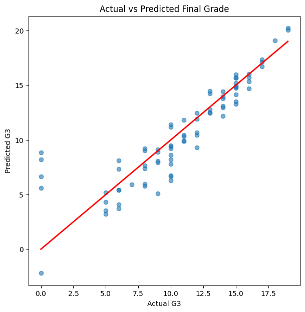

```python
plt.figure(figsize=(7, 7))
plt.scatter(y_test, y_pred, alpha=0.6)
plt.plot([y_test.min(), y_test.max()], [y_test.min(), y_test.max()], color='red', linewidth=2)
plt.xlabel("Actual G3")
plt.ylabel("Predicted G3")
plt.title("Actual vs Predicted Final Grade")
plt.show()
```